# Sick dataset analysis

Hubert Baniecki

2020-04-17

# Preprocessing

## Remove columns:

- `TBG` has one value
- `hypopituitary` has only one value (apart form 1 row)
- `TBG_measured` is all `NA`

```r
dataset_clean <- dataset_raw %>%
  select(-TBG, -TBG_measured, -hypopituitary) # one value / NA only
```

## Transform columns:

- `M, t, sick` => `1`
- `F, f, negative` => `0`

```r
temp <- dataset_clean

for (i in 1:ncol(temp)) {
  if (!is.null(levels(temp[[i]]))) {
    if (all(levels(temp[[i]]) %in% c("f", "t"))) {
      temp[i] <- as.numeric(ifelse(temp[i] == 't', 1, 0))
    }
  }
}
temp$sex <- ifelse(temp$sex == "M", 1, 0)
temp$Class <- as.factor(ifelse(temp$Class == "sick", 1, 0))

dataset <- temp
```

## Basic imputation (common sense):

- `age` : `454` and `NA` => `mean(age)` (2 rows)
- `sex` : if `pregnant==1` then `NA` => `0` (2 rows)

```r
dataset$age[dataset$age>100] <- mean(dataset$age[dataset$age<100], na.rm = TRUE)
dataset$age[is.na(dataset$age)] <- mean(dataset$age, na.rm = TRUE)
dataset$sex[dataset$pregnant==1] <- 0
```

# Base Models

## base lm model

It was bad.

## base rpart model

```r
temp <- dataset
temp$Class <- as.numeric(as.character(temp$Class))
train <- temp[index, ]
test <- temp[-index, ]

base_rpart <- rpart(Class~., data = train, method="anova", model = TRUE)
```

### The tree

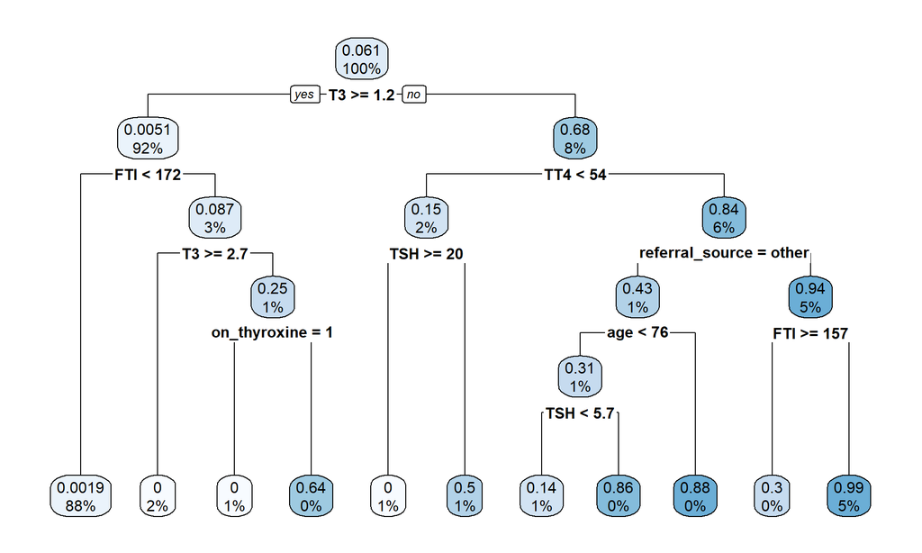

```r
rpart.plot::rpart.plot(base_rpart)
```

### test

```r
exp_base_rpart <- explain(base_rpart,
                          data = test,
                          y = test$Class,
                          model_info = list(type="classification"),
                          verbose=FALSE)

mp_test <- model_performance(exp_base_rpart)
mp_test$measures[c('auc')]
```

```
## $auc
## [1] 0.9937581
```

Calculate auprc.

```r
prob <- predict(base_rpart, test)
y_truth <- test$Class

fg <- prob[y_truth == 1]
bg <- prob[y_truth == 0]

# PR Curve
pr <- pr.curve(scores.class0 = fg, scores.class1 = bg, curve = T)
pr$auc.integral
```

```
## [1] 0.9249696
```

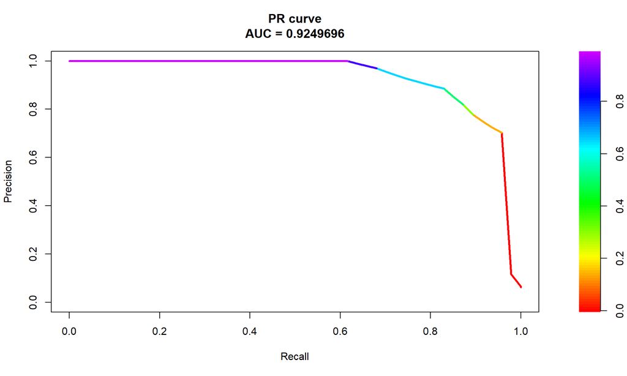

```r
plot(pr)
```

### train

```r
exp_train<- explain(base_rpart,
                          data = train,
                          y = train$Class,
                          model_info = list(type="classification"),
                          verbose=FALSE)

mp_train <- model_performance(exp_train)
mp_train$measures[c('auc')]
```

```
## $auc
## [1] 0.9899633
```

Calculate auprc.

```r
prob <- exp_train$y_hat
y_truth <- exp_train$y

fg <- prob[y_truth == 1]
bg <- prob[y_truth == 0]

# PR Curve
pr <- pr.curve(scores.class0 = fg, scores.class1 = bg, curve = T)
pr$auc.integral
```

```
## [1] 0.9555028
```

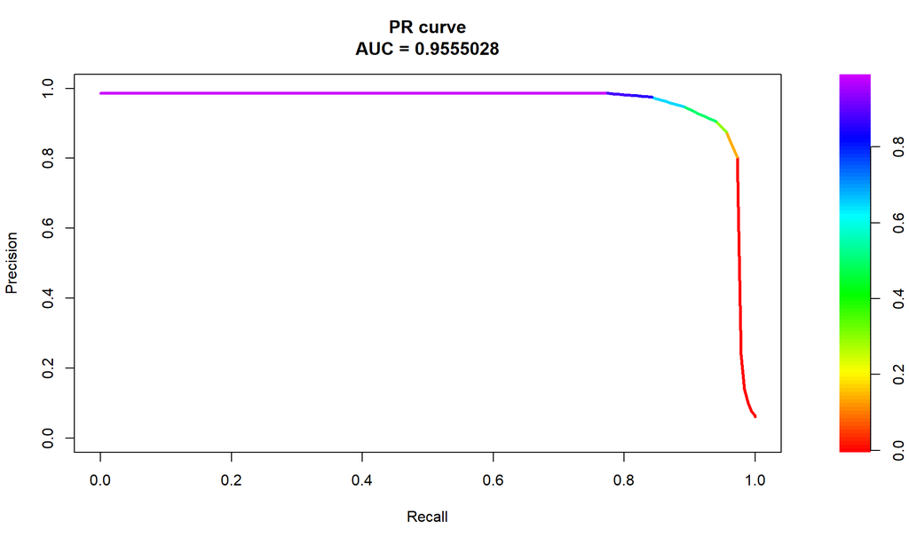

```r
plot(pr)
```

## Feature importance

Which columns are important? Can we remove some?

```r
data.frame(variable_importance=round(base_rpart$variable.importance,3))
```

|  | variable_importance |
| --- | --- |
| T3 | 105.730 |
| TT4 | 27.245 |
| FTI | 20.769 |
| TSH | 18.005 |
| referral_source | 8.651 |
| on_thyroxine | 4.968 |
| T3_measured | 3.225 |
| age | 3.114 |
| T4U | 1.955 |
| query_hypothyroid | 0.741 |
| TSH_measured | 0.209 |
| query_on_thyroxine | 0.161 |

# EDA

## vis_binary

Check if there are very similar columns (not really).

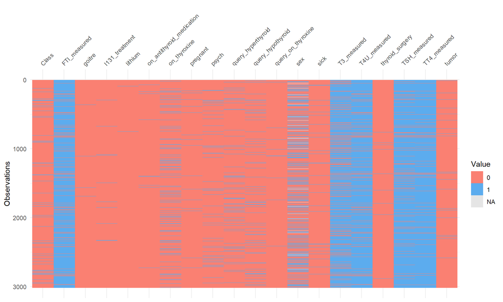

```r
dat_bin <- train %>% select(sex, on_thyroxine, query_on_thyroxine, on_antithyroid_medication, sick,
                              pregnant, thyroid_surgery, I131_treatment, query_hypothyroid, query_hyperthyroid,
                              lithium, goitre, tumor, psych, TSH_measured, T3_measured, TT4_measured, T4U_measured,
                              FTI_measured, Class)
visdat::vis_binary(dat_bin)
```

## Variable vs Target plots

### referral_source

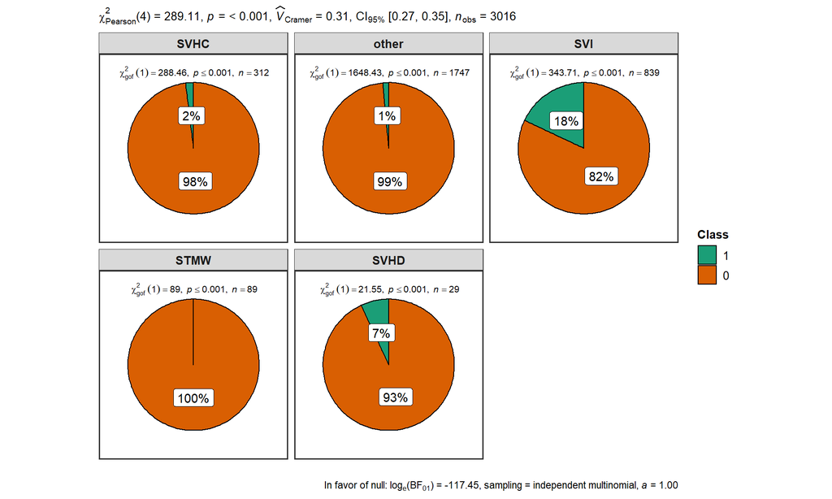

```r
sum(train$referral_source[train$Class==1]=="STMW")
```

```
## [1] 0
```

### tumor

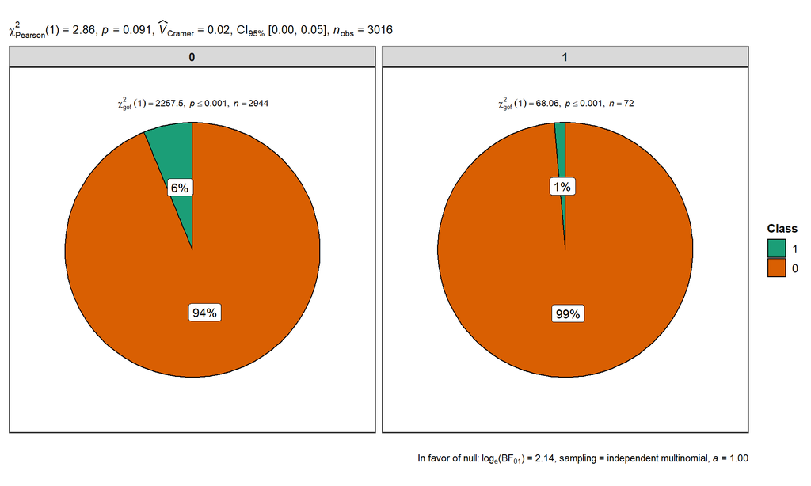

```r
sum(train$tumor[train$Class==1]==1)
```

```
## [1] 1
```

### I131_treatment

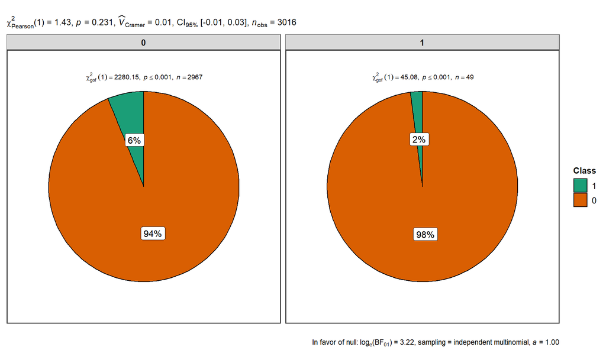

```r
sum(train$I131_treatment[train$Class==1]==1)
```

```
## [1] 1
```

### thyroid_surgery

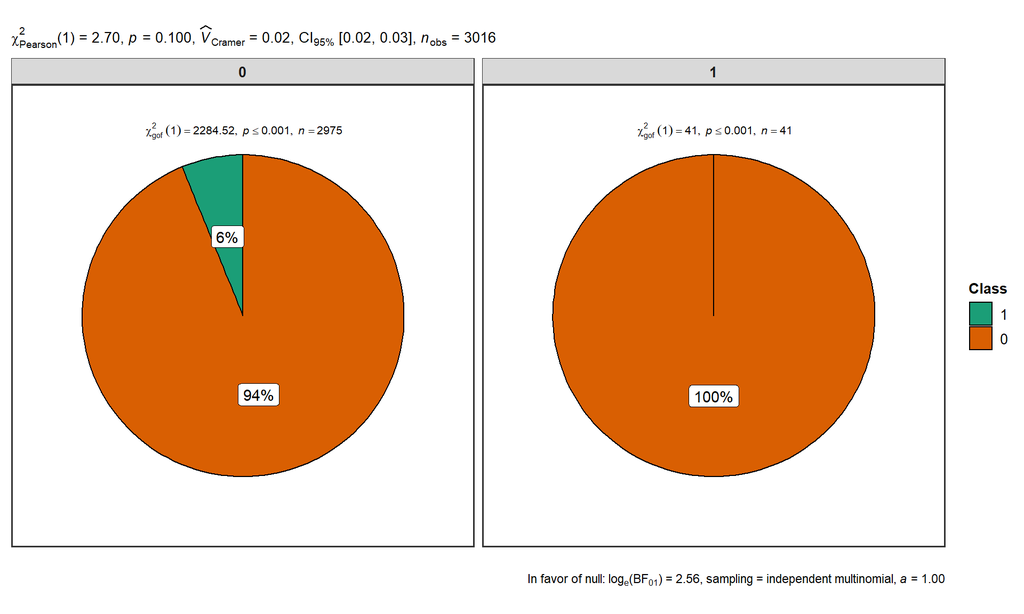

```r
sum(train$thyroid_surgery[train$Class==1]==1)
```

```
## [1] 0
```

### on_antithyroid_medication

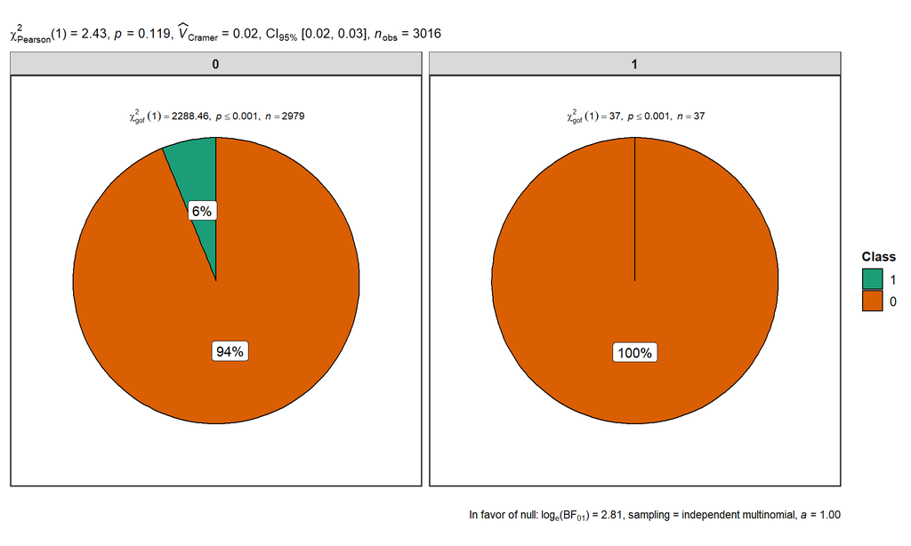

```r
sum(train$on_antithyroid_medication[train$Class==1]==1)
```

```
## [1] 0
```

### pregnant

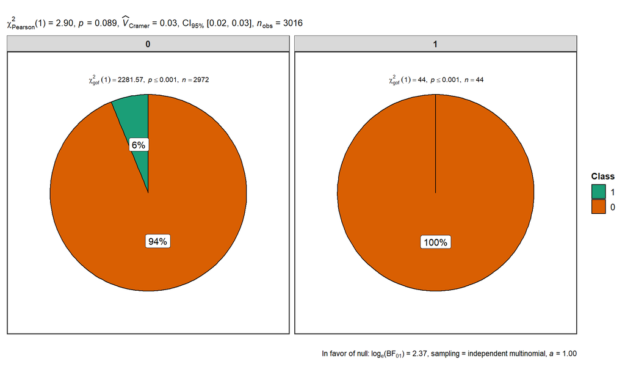

```r
sum(train$pregnant[train$Class==1]==1)
```

```
## [1] 0
```

### goitre

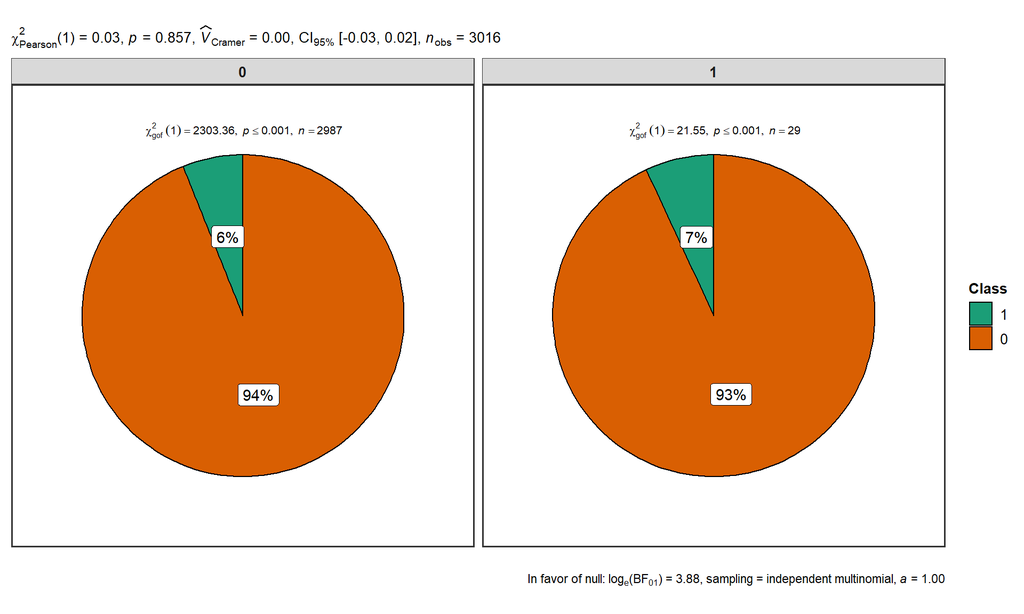

```r
sum(train$goitre[train$Class==1]==1)
```

```
## [1] 2
```

### lithium

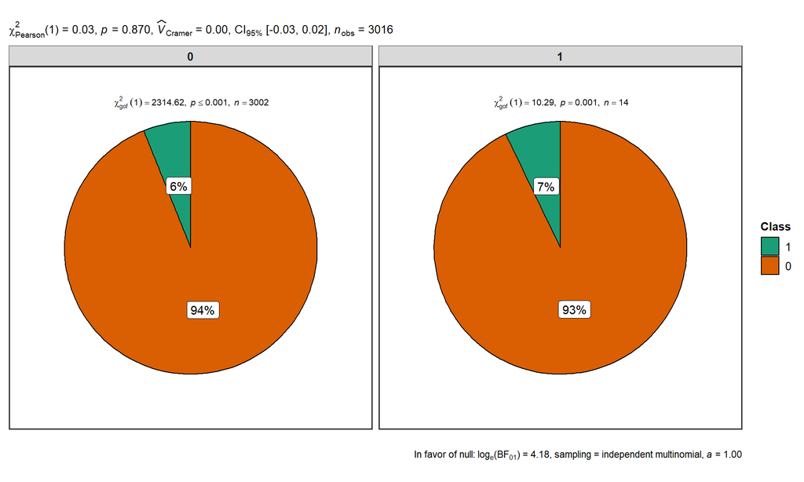

```r
sum(train$lithium[train$Class==1]==1)
```

```
## [1] 1
```

Not present columns had a lot more diversity. **Leave unchanged: sex, sick, psych, on_thyroxine, query_on_thyroxine, query_hypothyroid, query_hyperthyroid.**

## Measured vs Values

Here I focus on `TSH, TT4, T3, T4U, FTI` and corresponding `_measured` columns. Not measured means no value in the corresponding column. (measured `FALSE` => value `NA`)

At first, I checked the density of `value` for each `Class`. I later tried to impute `mean(column)` for specific `Class=1/0` but it didn’t change anything.

Secondly, I checked `_measured` columns . Below I aim to do the same as in the previous section.

### TSH

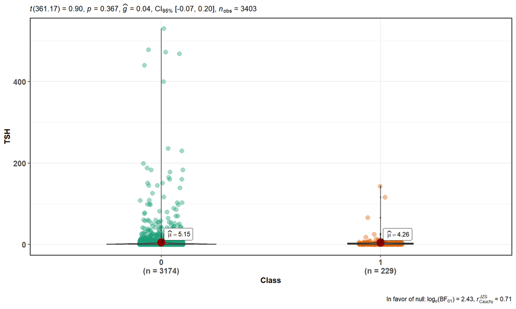

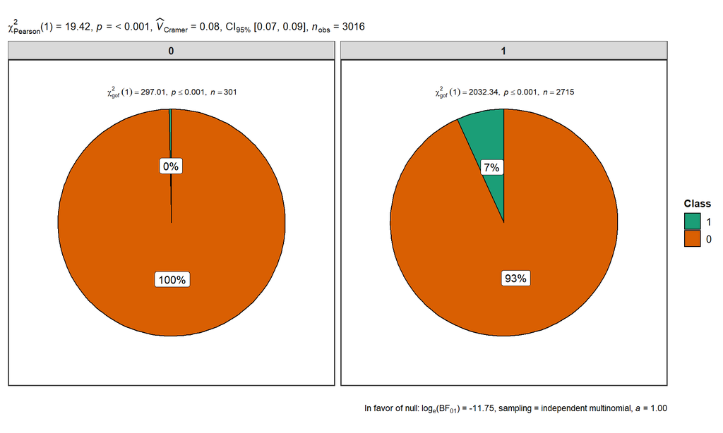

```r
sum(train$TSH_measured[train$Class==1]==0)
```

```
## [1] 1
```

### TT4

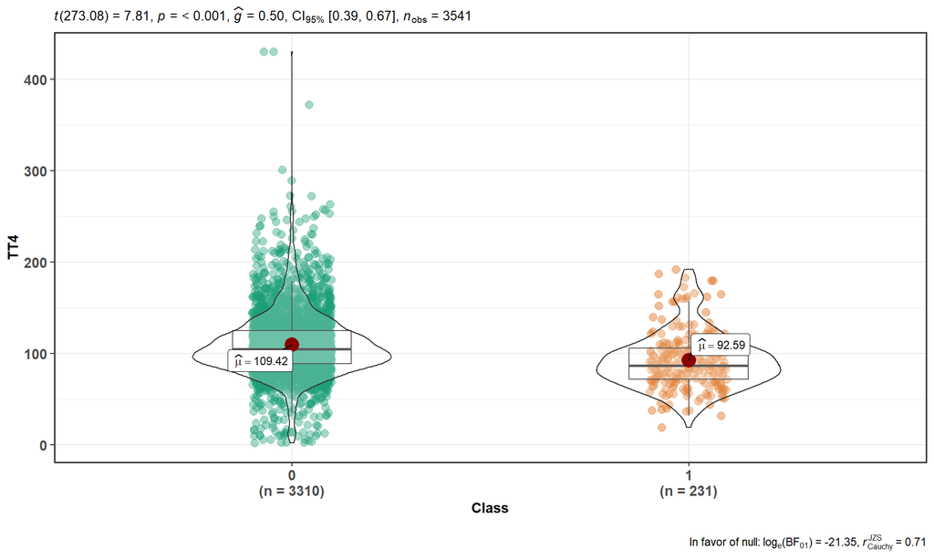

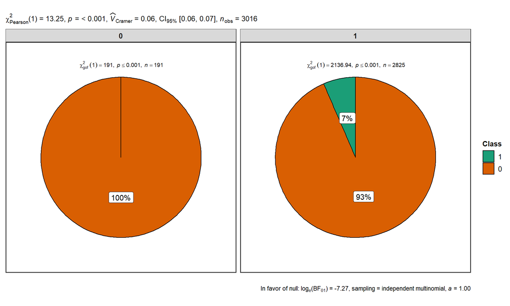

```r
sum(train$TT4_measured[train$Class==1]==0)
```

```
## [1] 0
```

### T3

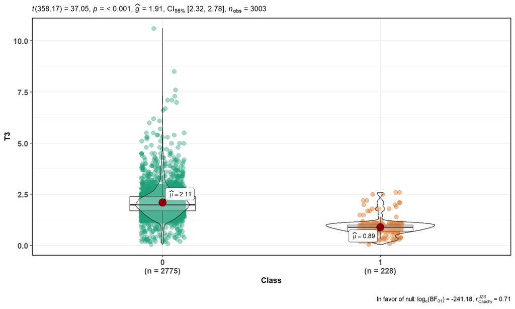

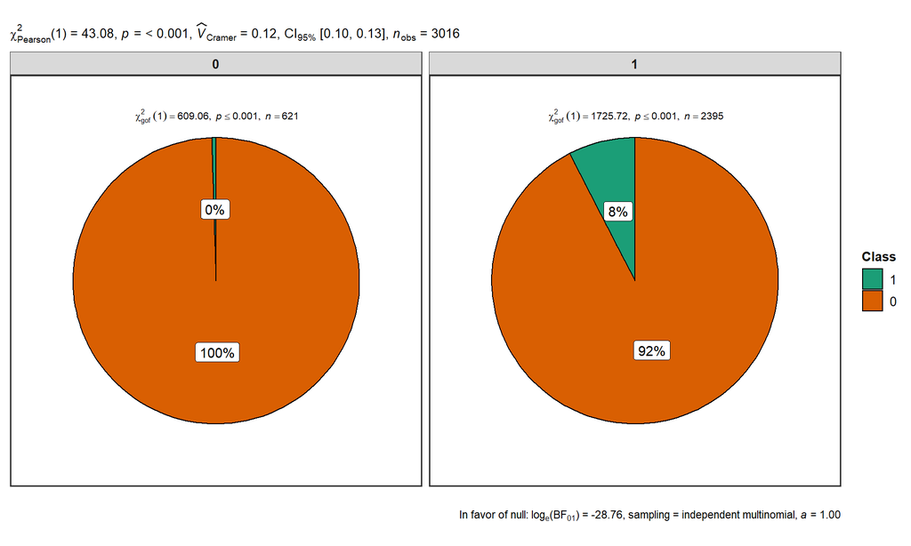

```r
sum(train$T3_measured[train$Class==1]==0)
```

```
## [1] 3
```

### T4U

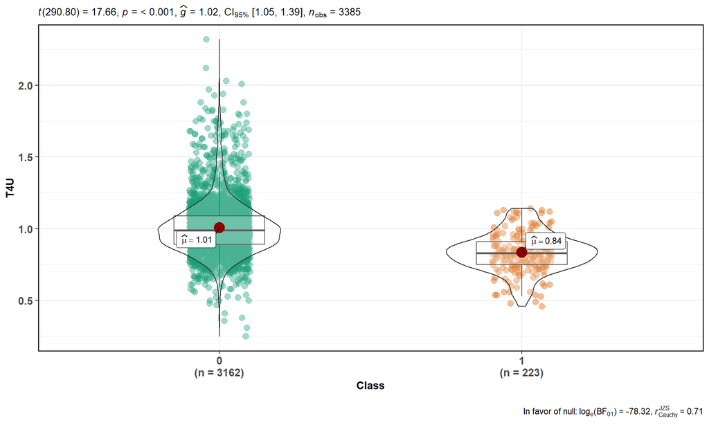

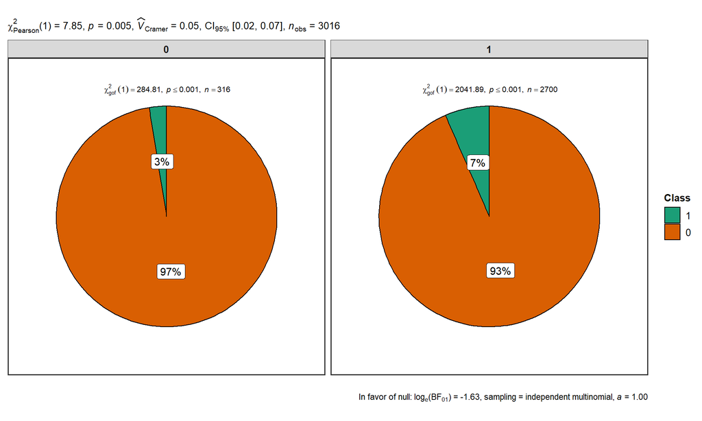

```r
sum(train$T4U_measured[train$Class==1]==0)
```

```
## [1] 8
```

### FTI

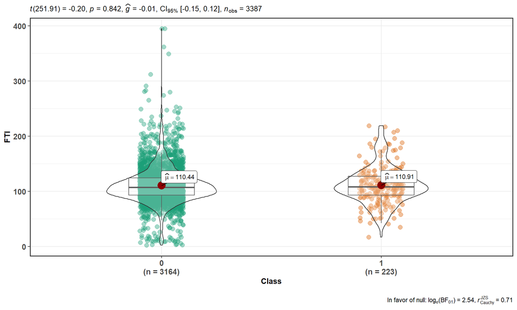

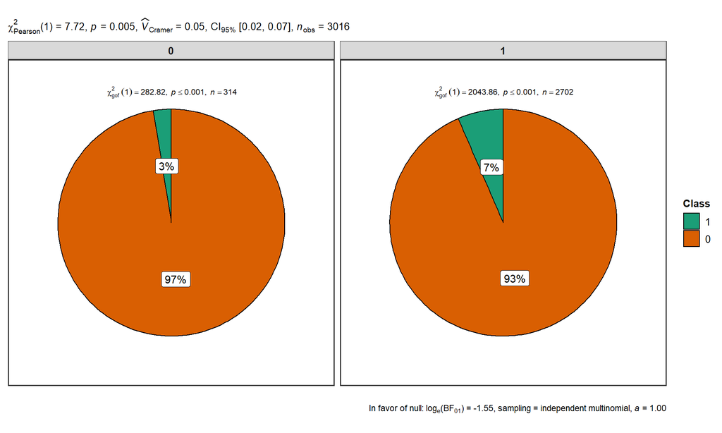

```r
sum(train$FTI_measured[train$Class==1]==0)
```

```
## [1] 8
```

# Experiments

## Experiment 1 - use EDA

Now, I use the information from `EDA` to filter `train` rows before training the model and `test` rows before making the prediction.

After removing these rows, 13 columns will have only one value, so they can be removed.

### pp()

Filter “for sure* negative” and remove 13 one-value columns.

```r
pp <- function(X) {
  X1 <- X %>% filter(
    referral_source=="STMW" | tumor==1 | I131_treatment==1 | thyroid_surgery==1 |
    on_antithyroid_medication==1 | pregnant==1 | goitre==1 | lithium==1 |
    TSH_measured==0 | TT4_measured==0 | T3_measured==0 | T4U_measured==0 | FTI_measured==0
  ) %>% select(-referral_source, -tumor, -I131_treatment, -thyroid_surgery,
               -on_antithyroid_medication, -pregnant, -goitre, -lithium,
               -TSH_measured, -TT4_measured, -T3_measured, -T4U_measured, -FTI_measured)

  X2 <- X %>% filter(
    referral_source!="STMW" & tumor!=1 & I131_treatment!=1 & thyroid_surgery!=1 &
    on_antithyroid_medication!=1 & pregnant!=1 & goitre!=1 & lithium!=1 &
    TSH_measured!=0 & TT4_measured!=0 & T3_measured!=0 & T4U_measured!=0 & FTI_measured!=0
  ) %>% select(-referral_source, -tumor, -I131_treatment, -thyroid_surgery,
               -on_antithyroid_medication, -pregnant, -goitre, -lithium,
               -TSH_measured, -TT4_measured, -T3_measured, -T4U_measured, -FTI_measured)

  list(X1, X2)
}
```

It works (rows are the same, columns are not the same)

```r
temp <- pp(dataset)
dim(temp[[2]])+dim(temp[[1]])==dim(dataset)
```

```
## [1]  TRUE FALSE
```

### experiment1()

This function uses `pp()` on both `train` and `test` to filter not needed rows.

`pp()` acts the same for both of the datasets and doesn’t use additional information from `test`.

After that, `auc` and `auprc` are caluclated.

```r
experiment1 <- function(trainX, testX) {

  ## preprocess
  pp_trainX <- pp(trainX) ## note: pp_trainX[1] is useless
  pp_testX <- pp(testX)

  ## first stage
  first_testX <- pp_testX[[1]]
  first_prob <- rep(mean(first_testX$Class), dim(first_testX)[1])
  first_y_truth <- first_testX$Class

  ## second stage
  second_testX <- pp_testX[[2]]
  second_trainX <- pp_trainX[[2]]

  model <- rpart(Class~., data = second_trainX)
  second_prob <- predict(model, second_testX)
  second_y_truth <- second_testX$Class

  ## glue
  prob <- c(first_prob, second_prob)
  y_truth <- c(first_y_truth, second_y_truth)

  ## AUC and AUPRC
  fg <- prob[y_truth == 1]
  bg <- prob[y_truth == 0]

  # ROC Curve
  roc <- roc.curve(scores.class0 = fg, scores.class1 = bg, curve = T)
  auc <- roc$auc
  # PR Curve
  pr <- pr.curve(scores.class0 = fg, scores.class1 = bg, curve = T)
  auprc <- pr$auc.integral

  list(auc=auc,auprc=auprc)
}

temp <- dataset
temp$Class <- as.numeric(as.character(temp$Class))
train <- temp[index, ]
test <- temp[-index, ]

set.seed(123)
sampling_index <- sample(1:dim(train)[1], dim(train)[1]/5) # take 20%
ttrain <- train[-sampling_index,]
ttest <- train[sampling_index,]

t(data.frame("cv1"=round(unlist(experiment1(ttrain, ttest)),3)))
```

```
##       auc auprc
## cv1 0.942 0.705
```

```r
t(data.frame("test"=round(unlist(experiment1(train, test)),3)))
```

```
##        auc auprc
## test 0.956 0.782
```

Unfortunatelly this experiment **didn’t work** (no point in doing more cv).

## Experiment 2 - Try to upgrade the base model

I tried:

- subseting different groups of columns
- multiple types of imputations
- hyperparameter tuning

First two didn’t help at all. Tunning the parameters made the model worse (on test) because it was overfitted to the training data.

# Final model

## CV1 function

```r
cv1 <- function(trainX, testX) {

  model <- rpart(Class~., data = trainX)
  prob <- predict(model, testX)
  y_truth <- testX$Class

  ## AUC and AUPRC
  fg <- prob[y_truth == 1]
  bg <- prob[y_truth == 0]

  # ROC Curve
  roc <- roc.curve(scores.class0 = fg, scores.class1 = bg, curve = T)
  auc <- roc$auc
  # PR Curve
  pr <- pr.curve(scores.class0 = fg, scores.class1 = bg, curve = T)
  auprc <- pr$auc.integral

  list("auc"=auc, "auprc"=auprc)
}

temp <- dataset
temp$Class <- as.numeric(as.character(temp$Class))
train <- temp[index, ]
test <- temp[-index, ]

results_train <- data.frame()

set.seed(123)

#:# do 5CV on train
for (i in 1:5) {
  sample_index <- sample(1:dim(train)[1], dim(train)[1]/5) # 20%
  ttrain <- train[-sample_index,]
  ttest <- train[sample_index,]
  ret <- cv1(ttrain, ttest)
  results_train <- rbind(results_train, ret)
}
```

## CV5 train

```r
t(data.frame("cv5"=round(unlist(colMeans(results_train)), 3)))
```

```
##       auc auprc
## cv5 0.972 0.908
```

## test

```r
results_test <- cv1(train, test)

t(data.frame("test"=round(unlist(results_test), 3)))
```

```
##        auc auprc
## test 0.976 0.925
```

## Tree plot

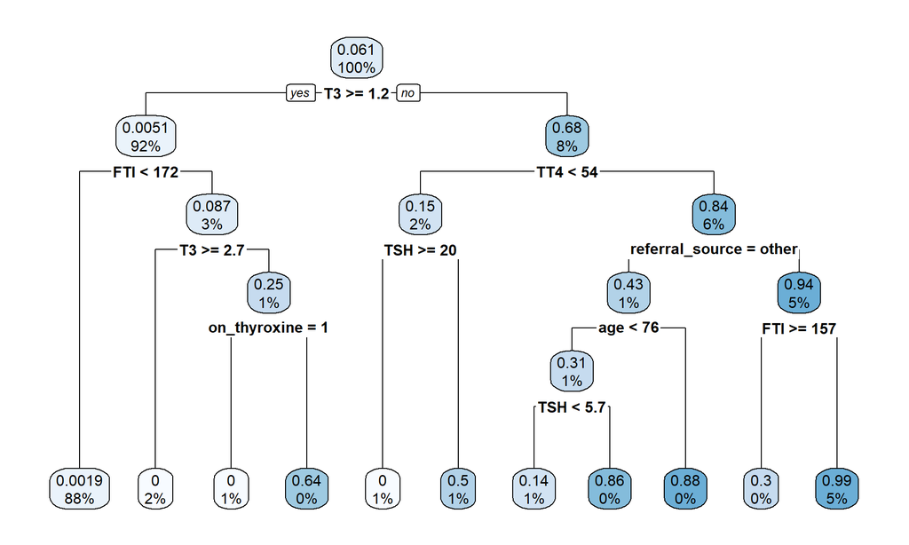

```r
model <- rpart(Class~., data = train, model=TRUE)
rpart.plot::rpart.plot(model)
```